# Árvore de Decisão para Regressão

```python
import pandas as pd
import numpy as np
import matplotlib.pyplot as plt
file_path = "../../files/"
```

## Base `plano_saude2.csv`

### PréProcessamento

```python
base = pd.read_csv(file_path + 'plano_saude2.csv')

X = base.iloc[:, 0:1].values
y = base.iloc[:, 1].values
```

### Classificador DecisionTreeRegressor

```python
from sklearn.tree import DecisionTreeRegressor
regressor = DecisionTreeRegressor()
regressor.fit(X, y)
```

```
DecisionTreeRegressor(ccp_alpha=0.0, criterion='mse', max_depth=None,
                      max_features=None, max_leaf_nodes=None,
                      min_impurity_decrease=0.0, min_impurity_split=None,
                      min_samples_leaf=1, min_samples_split=2,
                      min_weight_fraction_leaf=0.0, presort='deprecated',
                      random_state=None, splitter='best')
```

### Predizer exemplo

```python
regressor.predict(np.array(40).reshape(1, -1))
```

```
array([1150.])
```

### Gráfico

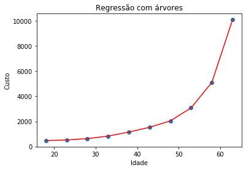

```python
import matplotlib.pyplot as plt
plt.scatter(X, y)
plt.plot(X, regressor.predict(X), color = 'red')
plt.title('Regressão com árvores')
plt.xlabel('Idade')
plt.ylabel('Custo')
```

### Criando dados de Teste, e testando

```python
X_teste = np.arange(min(X), max(X), 0.1)
X_teste = X_teste.reshape(-1,1)
```

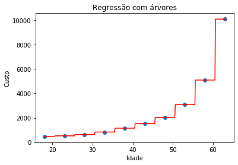

```python
plt.scatter(X, y)
plt.plot(X_teste, regressor.predict(X_teste), color = 'red')
plt.title('Regressão com árvores')
plt.xlabel('Idade')
plt.ylabel('Custo')
```

## Base `house_prices`

### PréProcessamento

```python
base = pd.read_csv(file_path + 'house-prices.csv')

X = base.iloc[:, 3:19].values
y = base.iloc[:, 2].values

from sklearn.model_selection import train_test_split
X_treinamento, X_teste, y_treinamento, y_teste = train_test_split(
    X, y, test_size = 0.3, random_state = 0)
```

### Classificador

```python
from sklearn.tree import DecisionTreeRegressor
regressor = DecisionTreeRegressor()
regressor.fit(X_treinamento, y_treinamento)
```

```
DecisionTreeRegressor(ccp_alpha=0.0, criterion='mse', max_depth=None,
                      max_features=None, max_leaf_nodes=None,
                      min_impurity_decrease=0.0, min_impurity_split=None,
                      min_samples_leaf=1, min_samples_split=2,
                      min_weight_fraction_leaf=0.0, presort='deprecated',
                      random_state=None, splitter='best')
```

```python
score = regressor.score(X_treinamento, y_treinamento)
score
```

```
0.9992712177726063
```

```python
previsoes = regressor.predict(X_teste)
```

### Avaliando o Regressor na base de `test`

```python
from sklearn.metrics import mean_absolute_error, mean_squared_error
mae = mean_absolute_error(y_teste, previsoes)
print("MAE - MeanAbsoluteError ==>", mae)
mse = mean_squared_error(y_teste, previsoes)
print("MSE - MeanSquareError   ==>", mse)
```

```
MAE - MeanAbsoluteError ==> 98927.44062307218
MSE - MeanSquareError   ==> 32993024436.60464
```

```python
regressor.score(X_teste, y_teste)
```

```
0.7596871189951414
```

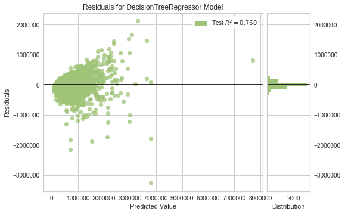

```python
from yellowbrick.regressor import ResidualsPlot
visualizer = ResidualsPlot(regressor)
visualizer.score(X_teste, y_teste)
visualizer.show()
```

## Base `Position_Salaries` English ML-AZ

```python
# Importing the dataset
dataset = pd.read_csv(file_path + 'Position_Salaries.csv')
X = dataset.iloc[:, 1:2].values
y = dataset.iloc[:, 2].values
```

```python
# Fitting Decision Tree Regression to the dataset
from sklearn.tree import DecisionTreeRegressor
regressor = DecisionTreeRegressor(random_state = 0)
regressor.fit(X, y)
```

```
DecisionTreeRegressor(ccp_alpha=0.0, criterion='mse', max_depth=None,
                      max_features=None, max_leaf_nodes=None,
                      min_impurity_decrease=0.0, min_impurity_split=None,
                      min_samples_leaf=1, min_samples_split=2,
                      min_weight_fraction_leaf=0.0, presort='deprecated',
                      random_state=0, splitter='best')
```

```python
# Predicting a new result
y_pred = regressor.predict([[6.5]])
```

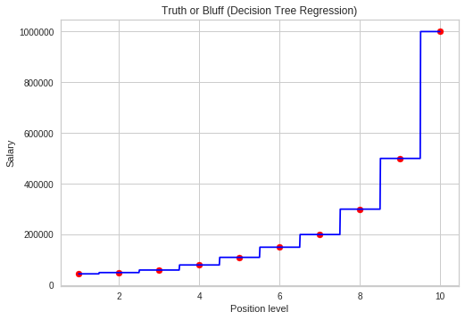

```python
# Visualising the Decision Tree Regression results (higher resolution)
X_grid = np.arange(min(X), max(X), 0.01)
X_grid = X_grid.reshape((len(X_grid), 1))
plt.scatter(X, y, color = 'red')
plt.plot(X_grid, regressor.predict(X_grid), color = 'blue')
plt.title('Truth or Bluff (Decision Tree Regression)')
plt.xlabel('Position level')
plt.ylabel('Salary')
plt.show()
```

## Question English ML-AZ Decision Tree Regression

### Decision Tree Regression Intuition

How does the algorithm split the data points?

It uses reduction of standard deviation of the predictions. In other words, the standard deviation is decreased right after a split. Hence, building a decision tree is all about finding the attribute that returns the highest standard deviation reduction (i.e., the most homogeneous branches).

What is the Information Gain and how does it work in Decision Trees?

The Information Gain in Decision Tree Regression is exactly the Standard Deviation Reduction we are looking to reach. We calculate by how much the Standard Deviation decreases after each split. Because the more the Standard Deviation is decreased after a split, the more homogeneous the child nodes will be.

What is the Entropy and how does it work in Decision Trees?

The Entropy measures the disorder in a set, here in a part resulting from a split. So the more homogeneous is your data in a part, the lower will be the entropy. The more you have splits, the more you have chance to find parts in which your data is homogeneous, and therefore the lower will be the entropy (close to 0) in these parts. However you might still find some nodes where the data is not homogeneous, and therefore the entropy would not be that small.

### Decision Tree Regression in Python

Does a Decision Tree make much sense in 1D?

Not really, as we saw in the practical part of this section. In 1D (meaning one independent variable), the Decision Tree clearly tends to overfit the data. The Decision Tree would be much more relevant in higher dimension, but keep in mind that the implementation we made here in 1D would be exactly the same in higher dimension. Therefore you might want to keep that model in your toolkit in case you are dealing with a higher dimensional space. This will actually be the case in Part 3 - Classification, where we will use Decision Tree for Classification in 2D, which you will see turns out to be more relevant.